# Figure 1: hnRNPH1 intron 4 decoy ggmsa plot

2026-03-18

### Data provenance

#### This figure is generated from the UCSC multiz MAF for chr5 and extracts the **hnRNPH1 intron 4 decoy** alignment from:

#### - **Region**: `chr5:179620560-179620600` (hg38 coordinates)

#### - **Extraction**: `mafsInRegion` from the Kent source tree (`kentUtils/src/hg/ratStuff/mafsInRegion`)

#### - `$ ../software/kent/binaries/./mafsInRegion hnRNPH1_intron4decoy.bed hnRNPH1_intron4decoy.maf chr5.maf.gz`

##### - chr5.maf.gz downloaded from https://hgdownload.soe.ucsc.edu/goldenPath/hg38/multiz100way/maf/chr5.maf.gz

#### - **MAF → FASTA conversion**: `msa_view` from the PHAST package converts maf file to fasta format with strand-aware logic

#### - `$ msa_view --in-format MAF --out-format FASTA hnRNPH1_intron4decoy.maf > hnRNPH1_intron4decoyMSA.fa`

#### In this markdown file, the extracted alignment FASTA `hnRNPH1_intron4decoyMSA.fa` is used to plot the alignment of the decoy 5’ consensus sequence conservation.

##### Below, we (1) plot this FASTA directly, then (2) create a manuscript-ready FASTA by renaming genome assemblies to common names, converting DNA (T) to RNA (U), removing a small set of taxa, removing all-gap/all-* columns, and finally (3) re-plot with highlighting around the proposed decoy site.

### Setup

```r
library(ggplot2)
library(ggmsa)
```

```r
# Load the hnRNPH1 decoy fasta produced in the heading

fasta <- file.path("../data/hnRNPH1_intron4decoyMSA.fa")
tree_clade_mapping_file <- file.path("../data/tree_to_clade_mapping.tsv")

fasta_processed <- file.path("../data/hnRNPH1_intron4decoyMSA.processed.fa")
```

### Plot the hnRNPH1 intron 4 decoy FASTA

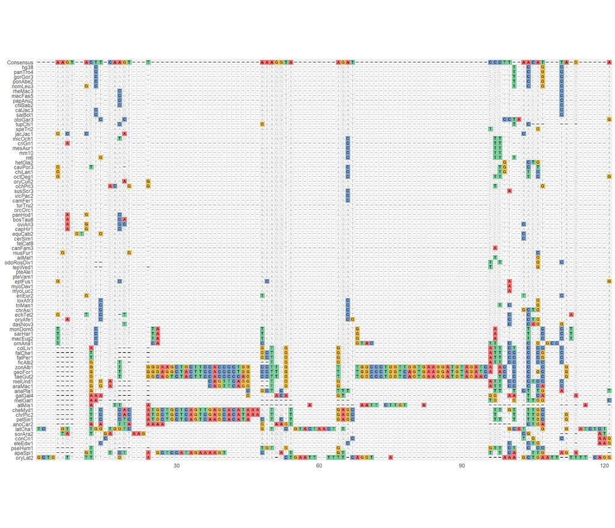

```r
p0 <- ggmsa(
  fasta,
  char_width = 0.6,
  seq_name = TRUE,
  consensus_views = TRUE,
  color = "Chemistry_NT"
)

print(p0)
```

### Convert the FASTA to a manuscript-ready version

```r
read_fasta_simple <- function(path) {
  x <- readLines(path)
  header_idx <- which(startsWith(x, ">"))
  seq_starts <- header_idx + 1
  seq_ends <- c(header_idx[-1] - 1, length(x))

  # Normalize by removing ">" + any whitespace and trim
  headers <- trimws(sub("^>\\s*", "", x[header_idx]))
  seqs <- vapply(
    seq_along(headers),
    function(i) paste0(x[seq_starts[i]:seq_ends[i]], collapse = ""),
    character(1)
  )

  names(seqs) <- headers
  seqs
}

write_fasta_simple <- function(seqs, path) {
  out <- unlist(Map(function(h, s) c(paste0(">", h), s), names(seqs), unname(seqs)))
  writeLines(out, path)
}

drop_all_gap_columns <- function(seqs) {
  m <- do.call(rbind, strsplit(seqs, "", fixed = TRUE))
  drop <- apply(m, 2, function(col) all(col %in% c("-", "*")))
  m2 <- m[, !drop, drop = FALSE]
  apply(m2, 1, paste0, collapse = "")
}
```

```r
# Load alignment
seqs <- read_fasta_simple(fasta)
names(seqs) <- trimws(names(seqs))

# Remove species with large insertions and poor conservation in the region of interest
remove_species <- c(
  "colLiv1", "falChe1", "falPer1", "ficAlb2", "zonAlb1", "geoFor1",
  "taeGut2", "melUnd1", "araMac1", "anaPla1", "galGal4", "melGal1",
  "allMis1", "cheMyd1", "chrPic2", "pelSin1", "anoCar2", "latCha1",
  "pseHum1", "apaSpi1", "oryLat2"
)
seqs <- seqs[!(names(seqs) %in% remove_species)]

# Rename genomes in FASTA headers to common names using the mapping file
tree_clade_map <- read.table(
  tree_clade_mapping_file,
  header = TRUE,
  sep = "\t",
  stringsAsFactors = FALSE,
  quote = "",
  comment.char = ""
)
species_id_to_common <- setNames(tree_clade_map$matched_common_name, tree_clade_map$species_id)
new_names <- unname(species_id_to_common[names(seqs)])
names(seqs) <- ifelse(is.na(new_names) | new_names == "", names(seqs), new_names)

# Convert DNA to RNA for plotting
seqs <- gsub("T", "U", seqs, fixed = TRUE)

# Remove columns that are gaps/missing across all species
seqs <- drop_all_gap_columns(seqs)

# Save processed FASTA for plotting
write_fasta_simple(seqs, fasta_processed)
```

### Plot the processed FASTA (with highlight at positions 27–33)

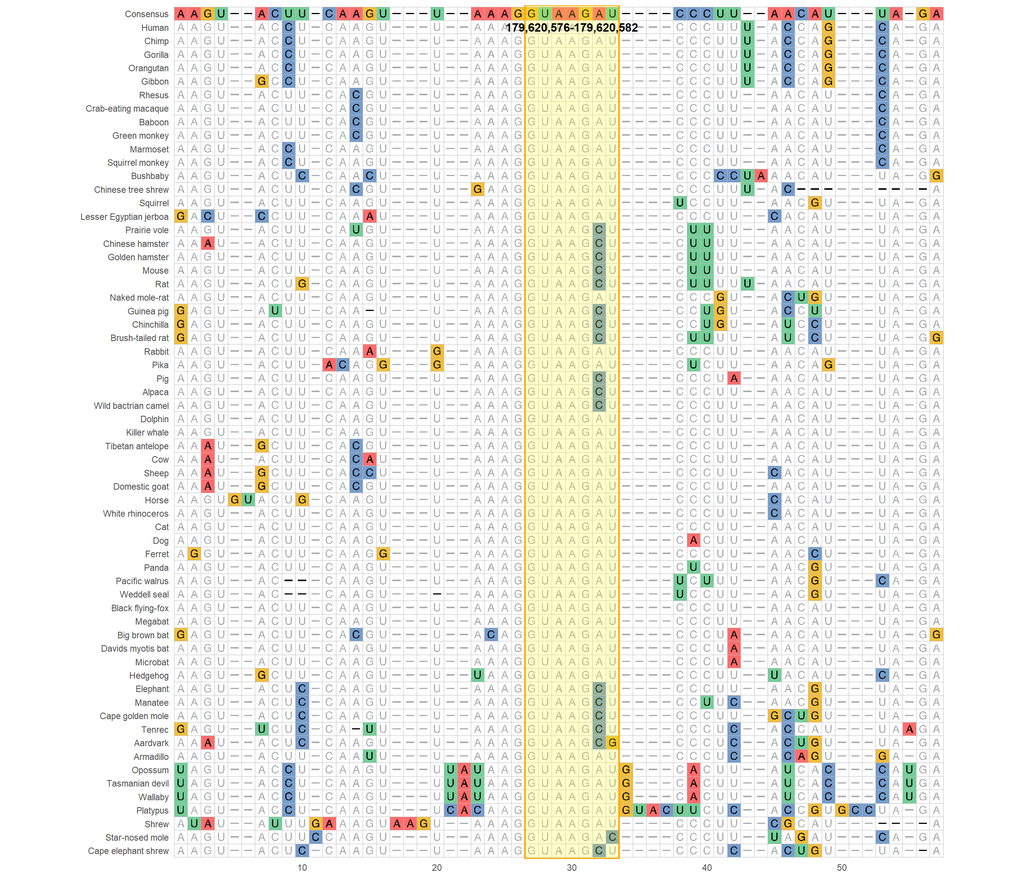

```r
seq_data <- readLines(fasta_processed)
seq_count <- sum(grepl("^>", seq_data))

p1 <- ggmsa(
  fasta_processed,
  char_width = 0.6,
  seq_name = TRUE,
  consensus_views = TRUE,
  color = "Chemistry_NT"
) +
  annotate(
    "rect",
    xmin = 27 - 0.5, xmax = 33 + 0.5,
    ymin = -Inf, ymax = Inf,
    alpha = 0.2, fill = "yellow", color = "orange", linewidth = 0.8
  ) +
  annotate(
    "text",
    x = 30, y = seq_count, label = "179,620,576-179,620,582",
    color = "black", fontface = "bold", size = 4
  )

print(p1)
```